# Multinomial Logistic Regression

Sprint1

Astijus Armonavicius

# 1. Introduction and data cleaning

Multinoimial regression contributes three things other methods cannot:

1. Directly interpretable coefficients. Each coefficient is a log-odds ratio for one outcome relative to a baseline.
2. It directly estimates probabilities for Home, Draw and Away.
3. It provides a benchmark for assessing whether more complex methods improve performance e.g. if random forests or SVMs perform similarly, their added complexity may offer little benefit.

## 1.2 Load the data and define the outcome

```r
train_raw <- read.csv("~/GitHub/Sprint-1/processed-data/football_train_data.csv", stringsAsFactors = FALSE)

test_raw <- read.csv("~/GitHub/Sprint-1/processed-data/football_test_data.csv", stringsAsFactors = FALSE)

# Match statistics used in the main analysis.
stats_all <- c(
  "HS", "AS", "HST", "AST", "HF", "AF",
  "HC", "AC", "HY", "AY", "HR", "AR"
)

# Bookmaker odds
# H = home win, D = draw, A = away win.
odds_cols <- c("B365H", "B365D", "B365A")

outcome_levels <- c("D", "A", "H")
```

## 1.3 Clean the rows and create simple features

We remove rows with missing outcomes or missing values in the 12 match statistics. This keeps model comparisons on the same matches. It may introduce bias if missingness is related to the match or league.

We also create differences (home minus away) and totals (home plus away). The difference describes which side has the advantage and the total describes the overall output during the match.

```r
prepare_matches <- function(data, predictors) {

  # Keep the original row number so predictions can be matched across models.
  data$source_row <- seq_len(nrow(data))

  keep <- complete.cases(data[, c("FTR", predictors), drop = FALSE])
  data <- data[keep, , drop = FALSE]

  # Differences
  data$d_sot <- data$HST - data$AST
  data$d_shots <- data$HS - data$AS
  data$d_corners <- data$HC - data$AC

  # Totals
  data$t_sot <- data$HST + data$AST
  data$t_shots <- data$HS + data$AS
  data$t_corners <- data$HC + data$AC

  data
}

# Main data
train_main <- prepare_matches(train_raw, stats_all)
test_main <- prepare_matches(test_raw, stats_all)

cat("Training rows in original file:", nrow(train_raw), "\n")
```

```
## Training rows in original file: 37824
```

```r
cat("Training rows used:", nrow(train_main), "\n")
```

```
## Training rows used: 37821
```

```r
cat("Premier League test rows in original file:", nrow(test_raw), "\n")
```

```
## Premier League test rows in original file: 8740
```

```r
cat("Premier League test rows used:", nrow(test_main), "\n")
```

```
## Premier League test rows used: 8740
```

# 2. Initial EDA

## 2.1 Compare the outcome balance

Home wins are the most common outcome in both the training and test data sets, with slightly more home wins in the Premier League sample. If we always predict a Home win this achieves $45.49\%$ test accuracy, providing a more meaningful baseline than $1/3\%$ accuracy.

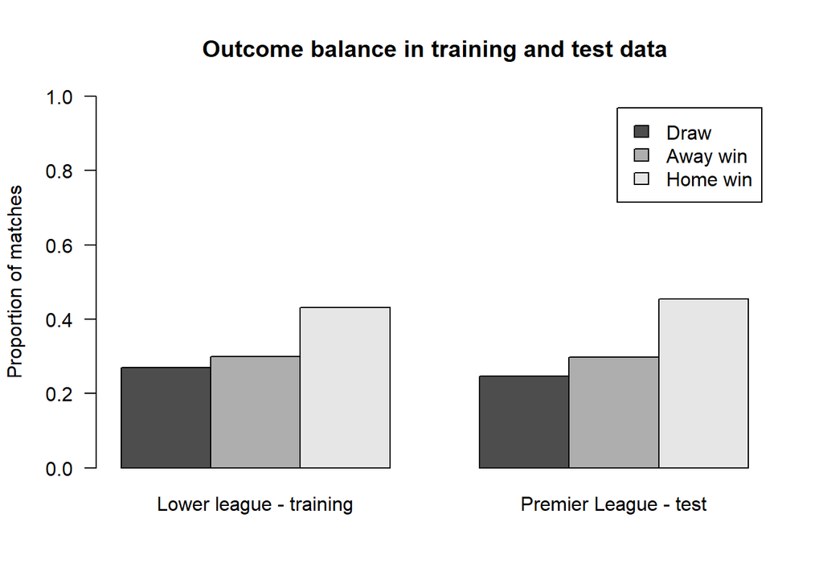

```r
class_share <- rbind(
  `Lower league - training` = prop.table(table(factor(train_main$FTR, levels = outcome_levels))),
  `Premier League - test` = prop.table(table(factor(test_main$FTR, levels = outcome_levels)))
)

colnames(class_share) <- c("Draw", "Away win", "Home win")

barplot(
  t(class_share), beside = TRUE,
  names.arg = rownames(class_share),
  legend.text = colnames(class_share),
  ylab = "Proportion of matches",
  main = "Outcome balance in training and test data",
  ylim = c(0, 1), las = 1
)
```

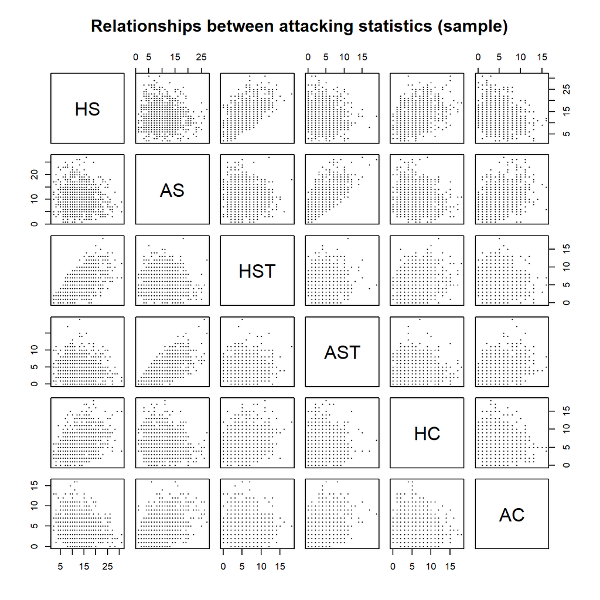

```r
idx <- sample(seq_len(nrow(train_main)), min(1500, nrow(train_main)))
pairs(train_main[idx, c("HS", "AS", "HST", "AST", "HC", "AC")],
      pch = 16, cex = 0.35, main = "Relationships between attacking statistics (sample)")
```

```r
round(cor(train_main[, stats_all]), 2)
```

```
##        HS    AS   HST   AST    HF    AF    HC    AC    HY    AY    HR    AR
## HS   1.00 -0.10  0.62 -0.08 -0.09  0.01  0.37 -0.19 -0.06  0.05 -0.10  0.10
## AS  -0.10  1.00 -0.09  0.63  0.03 -0.07 -0.20  0.37  0.08 -0.05  0.10 -0.11
## HST  0.62 -0.09  1.00  0.07 -0.03  0.02  0.26 -0.08 -0.09 -0.01 -0.06  0.10
## AST -0.08  0.63  0.07  1.00  0.03 -0.03 -0.08  0.26  0.02 -0.05  0.10 -0.07
## HF  -0.09  0.03 -0.03  0.03  1.00  0.16 -0.09 -0.02  0.31  0.07  0.05  0.03
## AF   0.01 -0.07  0.02 -0.03  0.16  1.00 -0.03 -0.07  0.06  0.33  0.03  0.06
## HC   0.37 -0.20  0.26 -0.08 -0.09 -0.03  1.00 -0.18 -0.07  0.03 -0.06  0.07
## AC  -0.19  0.37 -0.08  0.26 -0.02 -0.07 -0.18  1.00  0.02 -0.06  0.05 -0.07
## HY  -0.06  0.08 -0.09  0.02  0.31  0.06 -0.07  0.02  1.00  0.19  0.08  0.05
## AY   0.05 -0.05 -0.01 -0.05  0.07  0.33  0.03 -0.06  0.19  1.00  0.05  0.07
## HR  -0.10  0.10 -0.06  0.10  0.05  0.03 -0.06  0.05  0.08  0.05  1.00  0.06
## AR   0.10 -0.11  0.10 -0.07  0.03  0.06  0.07 -0.07  0.05  0.07  0.06  1.00
```

## 2.2 Check for redundancy

Shots and shots on target are moderately correlated for both home and away teams $(r=0.62, r=0.63)$. This suggests overlapping information and motivates comparing the full model with smaller alternatives

```
correlation_matrix <- cor(train_main[, stats_all])
corrplot(correlation_matrix, method = "color", addCoef.col = "black")
```

## 2.3 Look at the relationship between shot advantage and result

This plot groups matches by the difference between home and away shots on target. It shows whether home wins become more common as the home side’s advantage increases.

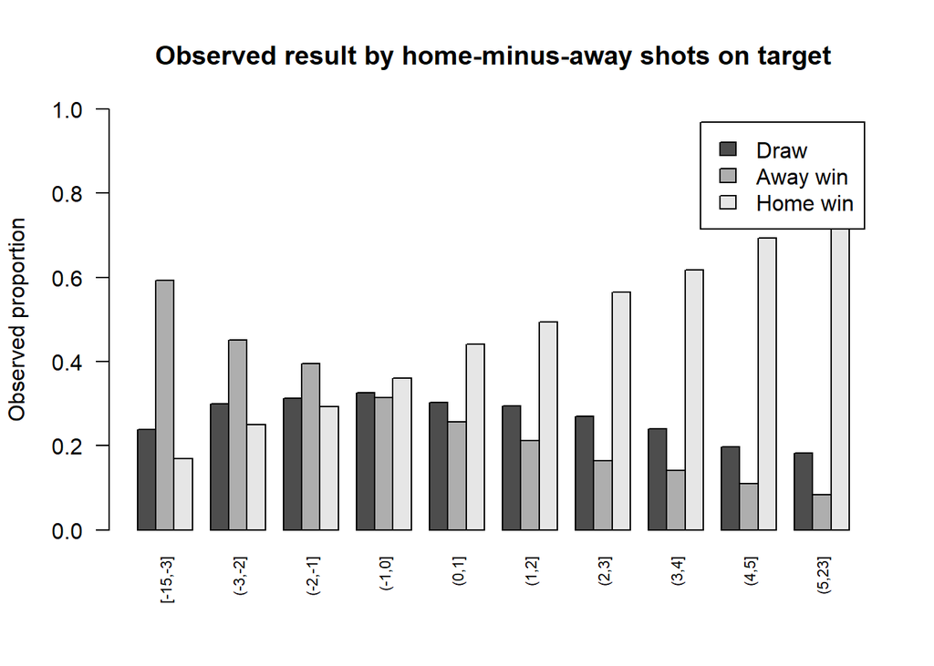

```r
# Use quantiles to make groups of roughly similar size.
cut_points <- unique(quantile(train_main$d_sot,probs = seq(0, 1, by = 0.1),))

shot_group <- cut(train_main$d_sot, breaks = cut_points, include.lowest = TRUE)
shot_group <- droplevels(shot_group)

result_by_shot_group <- prop.table(table(shot_group, factor(train_main$FTR, levels = outcome_levels)),margin = 1)

barplot(
  t(result_by_shot_group), beside = TRUE,
  names.arg = rownames(result_by_shot_group),
   legend.text = c("Draw", "Away win", "Home win"),
   ylab = "Observed proportion",
   main = "Observed result by home-minus-away shots on target",
   las = 2, cex.names = 0.7, ylim = c(0, 1)
)
```

We look at outcome proportions across shots on target differences to investigate how a relative attacking advantage relates to results. This motivates a difference based predictor and a sensitivity analysis excluding shots on target to see if we gain information by including it.

# 3. Model selection

## 3.1 What multinomial logistic regression estimates

The response has three unordered classes: draw, away win and home win. Multinomial logistic regression estimates a probability for each class, with the probabilities adding to one:

$$P(Y_i = k \mid \mathbf{x}_i) =
\frac{\exp(\alpha_k + \mathbf{x}_i^\top\boldsymbol{\beta}_k)}
{\sum_{j \in \{D,A,H\}} \exp(\alpha_j +
\mathbf{x}_i^\top\boldsymbol{\beta}_j)}.$$

This model estimates probabilities for Home, Draw and Away. With Draw as the reference, coefficients describe changes in home versus draw and away versus draw log-odds.

## 3.2 Models to compare

Each model addresses a specific question, whether shots on target dominate performance, whether other statistics add information, and whether an interaction improves fit. Backward selection tests whether a smaller model is sufficient.

1. **Null baseline:** intercept only
2. **Full statistics:** includes all 12 statistics
3. **Shots and corners:** a smaller model focused on attacking output
4. **Differences and totals:** differenced and total statistics between home and away
5. **Difference-total interaction:** interaction term
6. **Without shots on target:** checks whether the result depends heavily on SoT.
7. **Backward AIC:** starts with the full model and removes terms when it improves AIC.

Why I’ve chosen to investigate the interaction term ? A difference of two shots on target could mean 4 versus 2 or 12 versus 10. The difference is the same, but the overall match output is not. The interaction tests whether the relationship between the difference and outcome changes with the total and if it can accurately classify our matches.

```r
# Models I'd like to try.
formulas_main <- list(
  "Null baseline" = FTR ~ 1,

  "Only SoT" = FTR ~ HST + AST,

  "Full statistics" = FTR ~ HS + AS + HST + AST + HF + AF +
    HC + AC + HY + AY + HR + AR,

  "Shots and corners" = FTR ~ HST + AST + HS + AS + HC + AC,

  "Differences and totals" = FTR ~ d_sot + t_sot +
    d_shots + t_shots + d_corners + t_corners,

  "Difference-total interaction" = FTR ~ d_sot * t_sot +
    d_shots + t_shots + d_corners + t_corners,

  "Without shots on target" = FTR ~ HS + AS + HF + AF +
    HC + AC + HY + AY + HR + AR
)

# Model names
main_model_names <- c(names(formulas_main), "Backward AIC")

# Create empty list
main_fits <- list()

# Fit each model
for (model_name in main_model_names) {

  if (model_name == "Backward AIC") {

    full_fit <- multinom(
      FTR ~ HS + AS + HST + AST + HF + AF +
        HC + AC + HY + AY + HR + AR,
      data = train_main,
      maxit = 500,
      trace = FALSE
    )

    main_fits[[model_name]] <- stepAIC(
      full_fit,
      direction = "backward",
      trace = FALSE
    )

  } else {

    main_fits[[model_name]] <- multinom(
      formulas_main[[model_name]],
      data = train_main,
      maxit = 500,
      trace = FALSE
    )
  }
}
main_fits
```

```
## $`Null baseline`
## Call:
## multinom(formula = formulas_main[[model_name]], data = train_main,
##     maxit = 500, trace = FALSE)
##
## Coefficients:
##   (Intercept)
## D  -0.1008986
## H   0.3656743
##
## Residual Deviance: 81491.05
## AIC: 81495.05
##
## $`Only SoT`
## Call:
## multinom(formula = formulas_main[[model_name]], data = train_main,
##     maxit = 500, trace = FALSE)
##
## Coefficients:
##   (Intercept)       HST        AST
## D   0.2082358 0.1322254 -0.1959554
## H   0.2341527 0.3114793 -0.3322723
##
## Residual Deviance: 74724.6
## AIC: 74736.6
##
## $`Full statistics`
## Call:
## multinom(formula = formulas_main[[model_name]], data = train_main,
##     maxit = 500, trace = FALSE)
##
## Coefficients:
##   (Intercept)          HS         AS       HST        AST         HF
## D  -0.2490455 -0.02193981 0.04320808 0.1797689 -0.2788674 0.01448290
## H   0.4422467 -0.05475118 0.06540978 0.4321384 -0.4697306 0.01632194
##              AF         HC         AC          HY          AY         HR
## D -0.0005245382 -0.0190594 0.08660058 -0.02800315 0.009277620 -0.3646512
## H -0.0197184773 -0.1181351 0.11354535 -0.04047013 0.002617334 -0.8177238
##          AR
## D 0.4355663
```

[output cut: 69 more lines]

```
## $`Backward AIC`
## Call:
## multinom(formula = FTR ~ HS + AS + HST + AST + HF + AF + HC +
##     AC + HY + HR + AR, data = train_main, maxit = 500, trace = FALSE)
##
## Coefficients:
##   (Intercept)          HS         AS       HST        AST         HF
## D  -0.2469145 -0.02174199 0.04316774 0.1795656 -0.2789858 0.01438633
## H   0.4428999 -0.05468463 0.06539780 0.4320811 -0.4697855 0.01629734
##              AF          HC         AC          HY         HR        AR
## D  0.0004666966 -0.01896173 0.08649952 -0.02619201 -0.3629042 0.4370428
## H -0.0194538490 -0.11810236 0.11351511 -0.03994904 -0.8171215 0.8886191
##
## Residual Deviance: 72175.54
## AIC: 72223.54
```

## 3.3 ANOVA to test whether the statistics add information

First compare the SoT only model with the full model using a likelihood-ratio test. This tests whether the 12 predictors, considered together, improve fit over an SoT model.

```r
anova(main_fits[["Only SoT"]], main_fits[["Full statistics"]],test = "Chisq")
```

```
## Likelihood ratio tests of Multinomial Models
##
## Response: FTR
##                                                         Model Resid. df
## 1                                                   HST + AST     75636
## 2 HS + AS + HST + AST + HF + AF + HC + AC + HY + AY + HR + AR     75616
##   Resid. Dev   Test    Df LR stat. Pr(Chi)
## 1   74724.60
## 2   72174.86 1 vs 2    20 2549.748       0
```

Adding the remaining statistics to the shots on target model reduced deviance by $2549.75$. This supports using the additional parameters for our end model and that classification is not singularly dominated by the home and away shots on target statistic.

## 3.4 Compare models with AIC

AIC is a useful selection tool, but cannot be relied upon fully to select the ‘optimal model’

```r
# Compare AIC
main_aic <- data.frame(
  Model = main_model_names,
  AIC = NA_real_
)

for (i in seq_along(main_model_names)) {
  main_aic$AIC[i] <- AIC(main_fits[[main_model_names[i]]])
}

# Sort by lowest AIC
main_aic <- main_aic[order(main_aic$AIC), ]
main_aic
```

```
##                          Model      AIC
## 6 Difference-total interaction 71848.37
## 8                 Backward AIC 72223.54
## 3              Full statistics 72226.86
## 5       Differences and totals 72786.53
## 4            Shots and corners 72786.53
## 2                     Only SoT 74736.60
## 7      Without shots on target 78447.53
## 1                Null baseline 81495.05
```

The interaction model achieved the lowest AIC: $71848.37$. Backward selection removed “away yellow cards” as a predictor, but only slightly improved AIC over the full model.

# 4. Bookmaker odds

The three models below use only matches with complete values for all 12 match statistics and all three Bet365 odds columns.

```r
train_odds <- prepare_matches(train_raw, c(stats_all, odds_cols))
test_odds <- prepare_matches(test_raw, c(stats_all, odds_cols))

cat("Training rows in odds comparison:", nrow(train_odds), "\n")
```

```
## Training rows in odds comparison: 37812
```

```r
cat("Test rows in odds comparison:", nrow(test_odds), "\n")
```

```
## Test rows in odds comparison: 8740
```

Missing odds excluded nine additional training matches (approximately $0.024\%$) and no test matches. Although the training samples are almost identical, cross sample AIC comparisons are treated cautiously because the effect of these exclusions has not been looked into.

```r
# Models including bookmaker odds
formulas_odds <- list(

  "Bookmaker odds only" = FTR ~ B365H + B365D + B365A,

  "Statistics plus odds" = FTR ~ HS + AS + HST + AST + HF + AF +
    HC + AC + HY + AY + HR + AR + B365H + B365D + B365A,

  "Difference intercation plus odds" = FTR ~ d_sot * t_sot + d_shots +
    t_shots + d_corners + t_corners + B365H + B365D + B365A
)
# Model names
odds_model_names <- names(formulas_odds)

# Empty list
odds_fits <- list()

# Fit each model
for (model_name in odds_model_names) {

  odds_fits[[model_name]] <- multinom(
    formulas_odds[[model_name]],
    data = train_odds,
    maxit = 500,
    trace = FALSE
  )
}

# Compare AIC
odds_aic <- data.frame(
  Model = odds_model_names,
  AIC = NA_real_
)

for (i in seq_along(odds_model_names)) {
  odds_aic$AIC[i] <- AIC(odds_fits[[odds_model_names[i]]])
}

# Sort by lowest AIC
odds_aic <- odds_aic[order(odds_aic$AIC), ]
odds_aic
```

```
##                              Model      AIC
## 3 Difference intercation plus odds 70307.43
## 2             Statistics plus odds 70512.00
## 1              Bookmaker odds only 79000.42
```

# 5. Choosing a model

## 5.1 Select the final model

Our models are compared using AIC. The model with the lowest AIC is selected for further evaluation.

The Premier League test data is not used to select the model yet.

```r
total_aic <- rbind(main_aic, odds_aic)
total_aic <- total_aic[order(total_aic$AIC), ]
total_aic
```

```
##                               Model      AIC
## 31 Difference intercation plus odds 70307.43
## 21             Statistics plus odds 70512.00
## 6      Difference-total interaction 71848.37
## 8                      Backward AIC 72223.54
## 3                   Full statistics 72226.86
## 5            Differences and totals 72786.53
## 4                 Shots and corners 72786.53
## 2                          Only SoT 74736.60
## 7           Without shots on target 78447.53
## 11              Bookmaker odds only 79000.42
## 1                     Null baseline 81495.05
```

```r
selected_model <- total_aic$Model[1]
selected_fit <- total_aic$AIC[1]

cat("Selected model:", selected_model, "\n")
```

```
## Selected model: Difference intercation plus odds
```

```r
cat("Selected model AIC:", selected_fit, "\n")
```

```
## Selected model AIC: 70307.43
```

The model with interaction terms was preferred by AIC within both training sets, one with odds one without.

## 5.2 Define performance metrics

```r
score_predictions <- function(model, test_data) {
  # Predict probabilities
  probabilities <- predict(model, newdata = test_data, type = "probs")

  # Predict the outcome with the highest probability
  predicted <- colnames(probabilities)[max.col(probabilities)]

  # Percentage correct
  correct_percent <- mean(predicted == test_data$FTR) * 100

  # Calculate ROC curves and AUC
  roc_results <- list()
  auc_results <- numeric()

  for (outcome in colnames(probabilities)) {

    roc_results[[outcome]] <- roc(
      test_data$FTR == outcome,
      probabilities[, outcome],
      quiet = TRUE
    )

    auc_results[outcome] <- as.numeric(
      auc(roc_results[[outcome]])
    )
  }

  # Return results
  list(
    CorrectPercent = correct_percent,
    AUC = auc_results,
    ROC = roc_results
  )
}
```

# 6. Premier League test

## 6.1 Compare every main model

Every fitted model is evaluated on the same Premier League test rows.

```r
all_fits <- c(main_fits, odds_fits)

all_results <- list()

for (model_name in names(all_fits)) {

  if (model_name %in% names(odds_fits)) {
    all_results[[model_name]] <- score_predictions(
      all_fits[[model_name]],
      test_odds
    )
  } else {
    all_results[[model_name]] <- score_predictions(
      all_fits[[model_name]],
      test_main
    )
  }
}

# Create empty results table
results_table <- data.frame(
  Model = character(),
  AIC = numeric(),
  CorrectPercent = numeric(),
  AUC_Home = numeric(),
  AUC_Draw = numeric(),
  AUC_Away = numeric()
)

# Fill results table
for (model_name in names(all_fits)) {

  results_table[nrow(results_table) + 1, ] <- list(
    model_name,
    AIC(all_fits[[model_name]]),
    all_results[[model_name]]$CorrectPercent,
    all_results[[model_name]]$AUC["H"],
    all_results[[model_name]]$AUC["D"],
    all_results[[model_name]]$AUC["A"]
  )
}
# Round
results_table[, -1] <- round(results_table[, -1], 3)
results_table
```

```
##                               Model      AIC CorrectPercent AUC_Home AUC_Draw
## 1                     Null baseline 81495.05         45.492    0.500    0.500
## 2                          Only SoT 74736.60         55.984    0.740    0.585
## 3                   Full statistics 72226.86         57.117    0.756    0.602
## 4                 Shots and corners 72786.53         56.682    0.752    0.595
## 5            Differences and totals 72786.53         56.682    0.752    0.595
## 6      Difference-total interaction 71848.37         56.682    0.758    0.601
## 7           Without shots on target 78447.53         51.396    0.672    0.555
## 8                      Backward AIC 72223.54         57.071    0.756    0.602
## 9               Bookmaker odds only 79000.42         54.314    0.723    0.577
## 10             Statistics plus odds 70512.00         60.126    0.799    0.630
## 11 Difference intercation plus odds 70307.43         59.805    0.800    0.631
##    AUC_Away
## 1     0.500
## 2     0.757
## 3     0.771
## 4     0.765
## 5     0.765
## 6     0.772
## 7     0.686
## 8     0.770
## 9     0.737
## 10    0.815
## 11    0.815
```

The full model achieved $57.12\%$ accuracy, compared with $55.98\%$ using shots on target alone and 51.40% without them. Shots on target are therefore important, but do not capture all available information.

Adding bookmaker odds increased the full model’s accuracy to $60.13\%$, slightly exceeding the diffrence interaction with odds model’s $59.79\%$. Although AIC favoured the interaction model, the full statistics plus odds model achieved the highest test accuracy. This highlights that a better penalised training fit does not necessarily manifest into better classification performance.

## 6.3 ROC curves

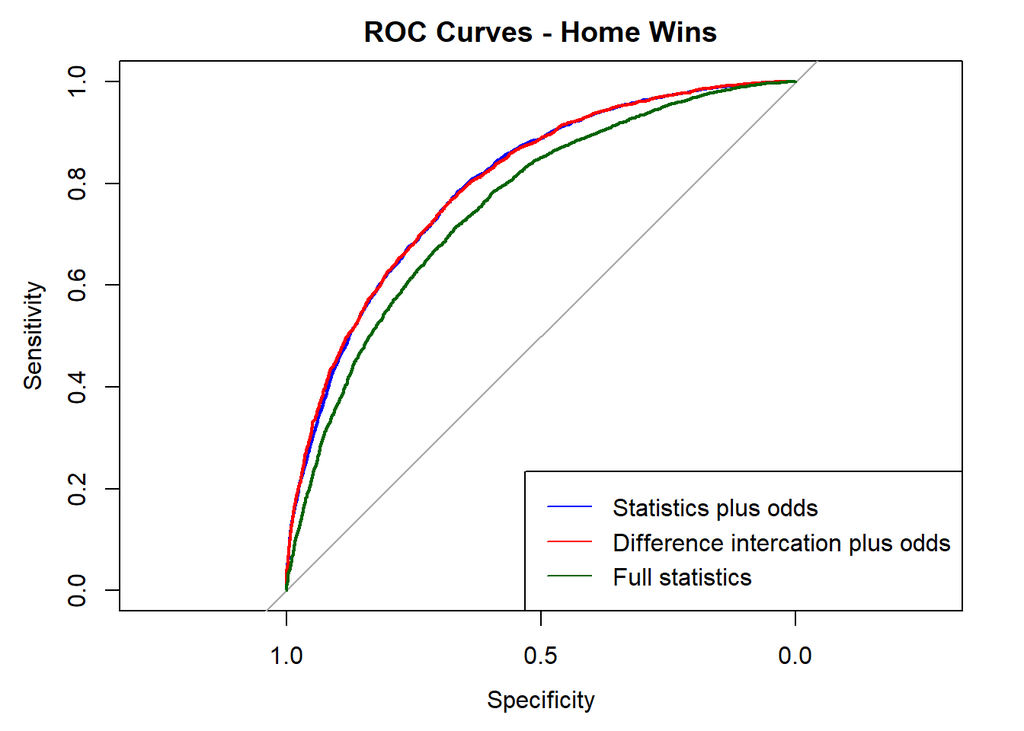

```r
# Sort models by percentage correct
results_table <- results_table[order(results_table$CorrectPercent, decreasing = TRUE), ]

# Select top 3
top_3 <- head(results_table$Model, 3)

# Set up colours for each model
model_colours <- c("blue", "red", "darkgreen")

# Plot ROC curves for home wins
plot(
  all_results[[top_3[1]]]$ROC[["H"]],
  col = model_colours[1],
  main = "ROC Curves - Home Wins"
)

for (i in 2:3) {
  plot(
    all_results[[top_3[i]]]$ROC[["H"]],
    col = model_colours[i],
    add = TRUE
  )
}

legend("bottomright", legend = top_3, col = model_colours, lty = 1)
```

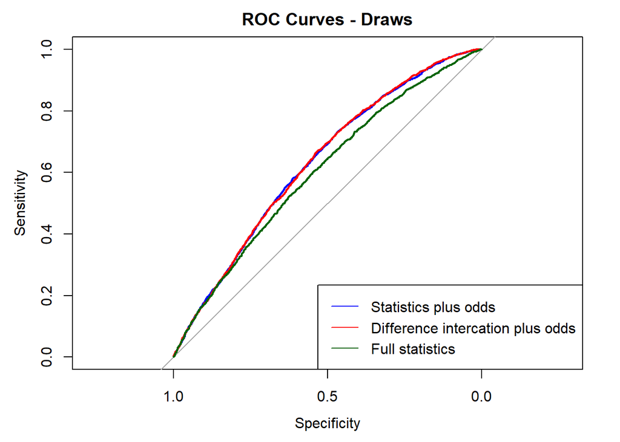

```r
# Plot ROC curves for draws
plot(
  all_results[[top_3[1]]]$ROC[["D"]],
  col = model_colours[1],
  main = "ROC Curves - Draws"
)

for (i in 2:3) {
  plot(
    all_results[[top_3[i]]]$ROC[["D"]],
    col = model_colours[i],
    add = TRUE
  )
}

legend("bottomright", legend = top_3, col = model_colours, lty = 1)
```

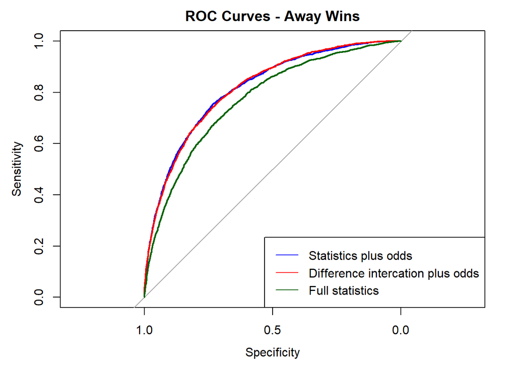

```r
# Plot ROC curves for away wins
plot(
  all_results[[top_3[1]]]$ROC[["A"]],
  col = model_colours[1],
  main = "ROC Curves - Away Wins"
)

for (i in 2:3) {
  plot(
    all_results[[top_3[i]]]$ROC[["A"]],
    col = model_colours[i],
    add = TRUE
  )
}

legend("bottomright", legend = top_3, col = model_colours, lty = 1)
```

The two odds enhanced models have almost identical ROC performance, with AUCs around $0.8$ for home wins, $0.815$ for away wins and $0.63$ for draws. Both outperform the full statistics model across all three outcomes.

Draws remain the hardest outcome to classify, even after introducing odds. One possible reason is that two teams can record similar shots and shots on target, yet one still wins narrowly. This overlap makes it harder for the model to identify a clear pattern separating draws from wins.

## 6.4 Confusion matrix

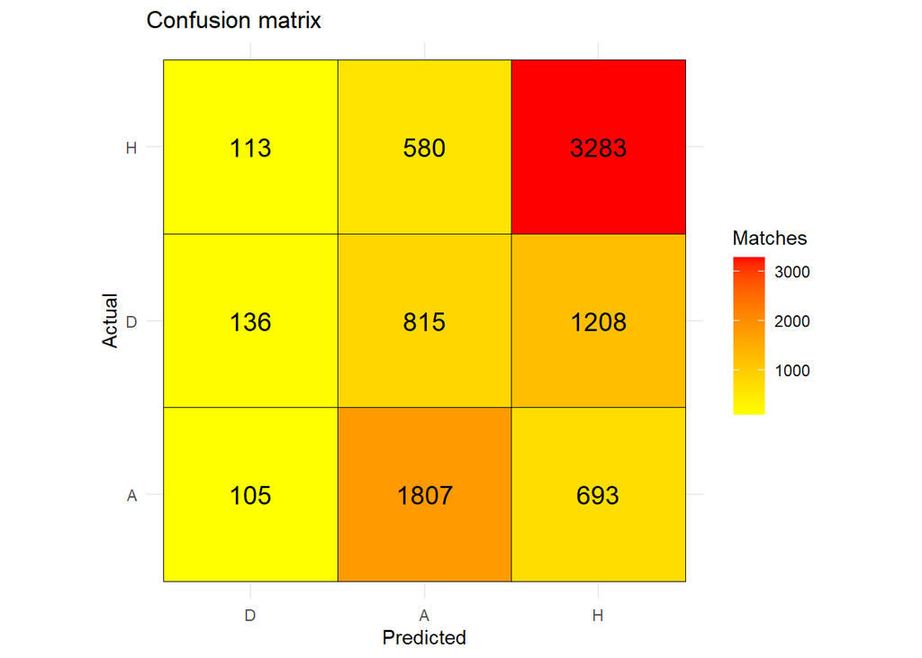

```r
fit <- odds_fits[["Difference intercation plus odds"]]

predicted <- predict(fit, newdata = test_odds, type = "class")

cm <- table(
  Actual = test_odds$FTR,
  Predicted = factor(predicted, levels = outcome_levels)
)

ggplot(as.data.frame(cm), aes(Predicted, Actual, fill = Freq)) +
  geom_tile(colour = "black") +
  geom_text(aes(label = Freq), size = 5) +
  scale_fill_gradient(low = "yellow", high = "red") +
  coord_equal() +
  labs(title = "Confusion matrix", fill = "Matches") +
  theme_minimal()
```

The confusion matrix displays a clear weakness in identifying draws, only $136$ of $2159$ actual draws were correctly classified ($6.3\%$), with most predicted as home wins. Alternatively, the model correctly identified $82.6\%$ of home wins and $69.4\%$ of away wins. We have a strong win classification but a very poor draw classification with this model.

# 7. Conclusion & Limitations

## 7.1 Conclusion

The full statistics plus odds model achieved the highest accuracy of $60.13\%$, compared with $45.49\%$ for the majority class baseline discussed in the initial EDA section.

Feature sensitivity analysis helped identify where the information came from. Using backwards AIC for the full model we identified, away yellow cards as the least important predictor. Removing shots on target reduced accuracy from $57.12\%$ to $51.40\%$, while the shots on target only model achieved $55.98\%$. Therefore SoT account for much but not all of the information/model’s performance. Adding bookmaker odds provided further gains to accuracy.

Our most important finding was a strong weakness of the model in predicting draws. The difference interaction plus odds model only correctly identified a shocking $6.3\%$ of actual draws, compared with a respectable $82.6\%$ of home wins and a moderate $69.4\%$ of away wins.

The confusion matrix changed our interpretation of our overall performance. The multinomial model was reasonably effective at identifying wins, but was not a balanced three outcome classifier, especially for draws.

## 7.2 Limits of the data set

The available data limits how accurately we can distinguish draws from narrow victories. Similar numbers of shots, shots on target and corners can classify either result, leaving no clear statistical separation. Adding more parameters cannot fully compensate for missing information.

## References

- University of Bristol, Data Science Toolbox https://dsbristol.github.io/dst/coursebook.html
- University of Bristol, Linear and Generalised Linear Models (MATH30013) lecture notes